#optimal number Elbow Method for determining the optimal number of clusters (K) in a k-means clustering algorithm. The Elbow Method helps identify a suitable value for K by plotting the Total Within Sum of Squares (WSS) against different values of K.

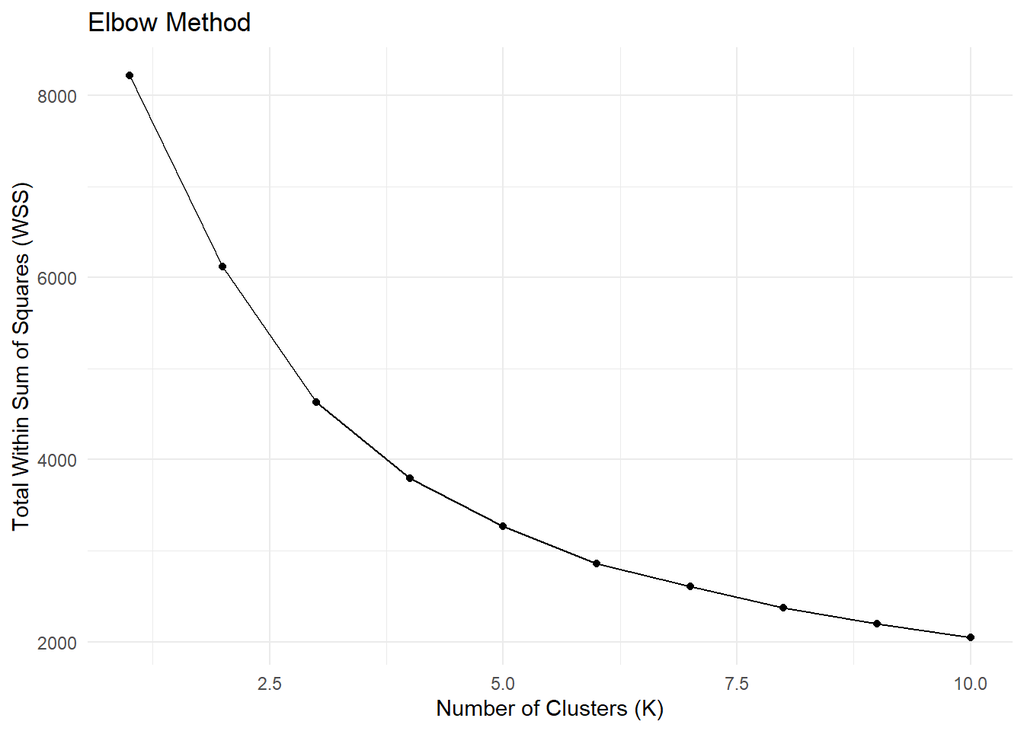

```r
#Elbow method
wss <- numeric(10)

for (i in 1:10) {
  set.seed(123) # For reproducibility
  kmeans_result <- kmeans(data_pca_df, centers = i, nstart = 25)
  wss[i] <- kmeans_result$tot.withinss
}

# Creating the Elbow Plot
k_values <- 1:10 # Adjust the range as needed
elbow_plot <- data.frame(k_values, wss)
ggplot(elbow_plot, aes(x = k_values, y = wss)) +
  geom_line() +
  geom_point() +
  theme_minimal() +
  labs(title = "Elbow Method", x = "Number of Clusters (K)", y = "Total Within Sum of Squares (WSS)")
```

```r
optimal_k <- which.min(wss)
k_values <- c(optimal_k, optimal_k - 1, optimal_k + 1)
# Print the K values
cat("Optimal K value is:", optimal_k, "\n")
```

```
## Optimal K value is: 10
```

```r
cat("K value immediately before the optimal K is:", optimal_k - 1, "\n")
```

```
## K value immediately before the optimal K is: 9
```

```r
cat("K value immediately after the optimal K is:", optimal_k + 1, "\n")
```

```
## K value immediately after the optimal K is: 11
```

The output of this code will include the Elbow Plot and information about the optimal K value, as well as the K values immediately before and after the optimal K. The user can visually inspect the plot to identify the “elbow” point, which represents the optimal number of clusters for the k-means algorithm based on the WSS criterion

#calculate k-mean k=2,3,4 and plot

```r
# Load necessary library for visualization
library(factoextra)
```

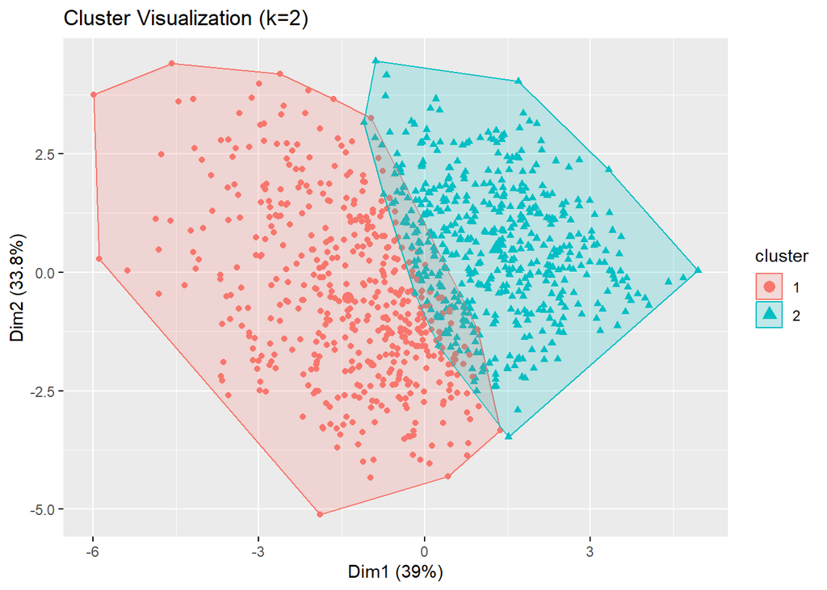

```r
# Clustering and plotting for k = 2, 3, and 4 as they were most significant from the elbow plot
set.seed(123)  # For reproducibility

dist_matrix <- dist(data)
# Clustering for k = 2
k2 <- kmeans(data_pca_df, centers = 2, nstart = 25)
fviz_cluster(k2, data = data_pca_df, geom = "point",
             stand = FALSE, ellipse  = TRUE,
             main = "Cluster Visualization (k=2)")
```

```r
print(paste("Total WSS for k=2:", k2$tot.withinss))
```

```
## [1] "Total WSS for k=2: 6122.19780057585"
```

```r
sil_widths2 <- silhouette(k2$cluster, dist_matrix)
avg_sil_width2 <- mean(sil_widths2[, "sil_width"])
print(paste("Average Silhouette Width for k=2:", avg_sil_width2))
```

```
## [1] "Average Silhouette Width for k=2: 0.0447772146462416"
```

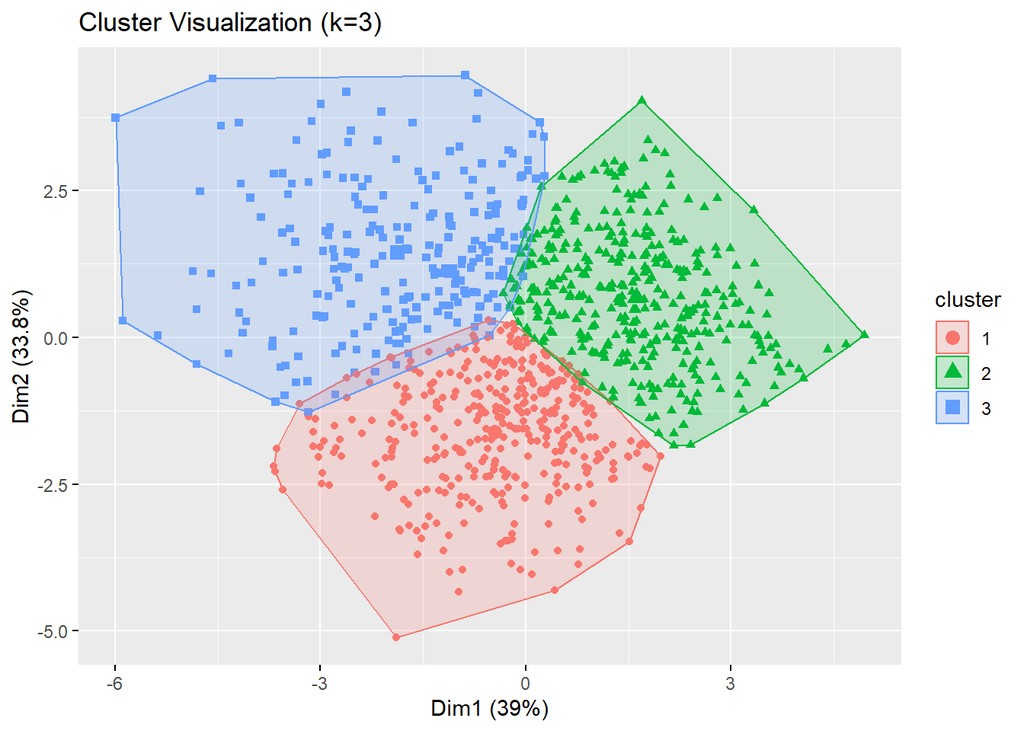

```r
# Clustering for k = 3
k3 <- kmeans(data_pca_df, centers = 3, nstart = 25)
fviz_cluster(k3, data = data_pca_df, geom = "point",
             stand = FALSE, ellipse  = TRUE,
             main = "Cluster Visualization (k=3)")
```